# 00_all

Author

Lucía de Lamadrid, Eric Torres, Konstantina Gkopi and Jorge Santiago

# Main report

This document compiles all the other Quarto documents:

## Load data

### 1. Load packages

```r
library(tidyverse)
library(googledrive)
library(readr)
```

### 2. Download and read files

```r
# Definition of the folder where we want the data in
target_folder <- "../_raw"

# Check if the folder exists; create it if not
if (!dir.exists(target_folder)) {
  dir.create(target_folder)
  message("Created folder: ", target_folder)
} else {
  message("Folder already exists: ", target_folder)
}
```

```
Folder already exists: ../_raw
```

```r
# File ID on Google Drive
file_id <- "1CW63f5yjQsfovsbEJECvi1NlxkAIEer4"

# Definition of the path where it will be downloaded it
dest_path <- file.path(target_folder, "MicrobiomeOTUtaxonomy.zip")

# Download the file into _raw
drive_download(as_id(file_id), path = dest_path, overwrite = TRUE)
```

[output not shown]

[output not shown]

[output not shown]

[output not shown]

```
File downloaded:
```

```
• 'MicrobiomeOTUTaxonomy.zip' <id: 1CW63f5yjQsfovsbEJECvi1NlxkAIEer4>
```

```
Saved locally as:
```

```
• '../_raw/MicrobiomeOTUtaxonomy.zip'
```

```r
# Unzip
unzip(dest_path, exdir = target_folder)
```

```r
# Load the main data file
raw_dir <- "../_raw"
data_file_metadata <- "/data_zip/MicrobiomeWithMetadata.csv"
data_file_dictionary <- "/data_zip/MicrobiomeMetadataDictionary.csv"
data_file_otu <- "/data_zip/MicrobiomeOTUtaxonomy.csv"

data_path_metadata = str_c(raw_dir,data_file_metadata)
data_path_dictionary = str_c(raw_dir,data_file_dictionary)
data_path_otu = str_c(raw_dir,data_file_otu)
```

```r
# Load data
metadata_df <- read_csv(data_path_metadata)
dictionary_df <- read_csv(data_path_dictionary)
otu_df <- read_csv(data_path_otu)
```

In the `otu_df` there are two types of separators (`\t` followed by `,`) in the first column, so we will eliminate the `\t` to have a uniform data frame.

```r
otu_df <- otu_df |>
  mutate(across(everything(), ~gsub("\t", "", .x)))
# change columns in all dataset taken from "https://stackoverflow.com/questions/43456687/using-dplyr-gsub-on-many-columns"
```

### 3. Create .tsv files

```r
if (!dir.exists("../data")) {
  dir.create("../data")
}

metadata_df |>
  write_tsv(file = "../data/01_data_metadata.tsv")

dictionary_df |>
  write_tsv(file = "../data/01_data_dictionary.tsv")

otu_df |>
  write_tsv(file = "../data/01_data_otu.tsv")
```

## Clean data

### 1. Load packages

### 2. Read data

```r
metadata_df <- read.table('../data/01_data_metadata.tsv', header=TRUE, sep='\t')
head(metadata_df)
```

[output not shown]

We are going to check if there are missing values (NA):

```r
na_check <- anyNA(metadata_df)
na_check
```

```
[1] FALSE
```

Is the value relative abundance? It is, as the total value of each row is 1.

```r
otu_columns <- select(metadata_df, starts_with("OTU"))
row_sums <- rowSums(otu_columns)
summary(row_sums)
```

```
   Min. 1st Qu.  Median    Mean 3rd Qu.    Max.
      1       1       1       1       1       1
```

### 3. Clean data

A dataset is tidy when:

- Each variable is a column
- Each observation is a row
- Each value is a cell

First, we will create a SampleID column.

```r
# Creation and relocation of SampleID
metadata_df <- metadata_df |>
  mutate(SampleID = row_number()) |>  # Create SampleID from the first column
  relocate(SampleID, .before = everything())  # Move SampleID to the first position
head(metadata_df)
```

[output not shown]

In the dataset we are working with, there are columns (`OTU0`- `OTU-6695`) in which the column names are one variable (`OTU`) and the cell values are another variable (`rel_abundance`). To do some tidying, we are going to use `pivot_longer()`:

```r
metadata_df_long <- metadata_df |>
  pivot_longer(
    cols = starts_with("OTU"),
    names_to = "OTU",
    values_to = "rel_abundance"
  )
dim(metadata_df_long)
```

```
[1] 4519800       8
```

As a result, we get a dataframe of $N = 4,519,800$ !

**Exploring OTU Abundance Distributions and Determining Filtering Thresholds**

To reduce the size of the dataset from the original $N = 4,519,800$ rows and focus on meaningful OTUs, we apply filtering to remove low-abundance and negligible contributors.

We calculated the mean relative abundance of each OTU, ranked them in descending order, computed their cumulative contribution to total abundance, and plotted a cumulative contribution curve to identify key OTUs contributing significantly to the microbiome.

```r
# Calculate cumulative contribution
cumulative_otus <- metadata_df_long |>
  group_by(OTU) |>
  summarize(mean_abundance = mean(rel_abundance)) |>
  arrange(desc(mean_abundance)) |>
  mutate(cumulative_abundance = cumsum(mean_abundance) / sum(mean_abundance))

head(cumulative_otus)
```

```
# A tibble: 6 × 3
  OTU     mean_abundance cumulative_abundance
  <chr>            <dbl>                <dbl>
1 OTU4496         0.115                 0.115
2 OTU4154         0.0731                0.188
3 OTU3857         0.0413                0.229
4 OTU618          0.0333                0.262
5 OTU5948         0.0306                0.293
6 OTU5429         0.0288                0.322
```

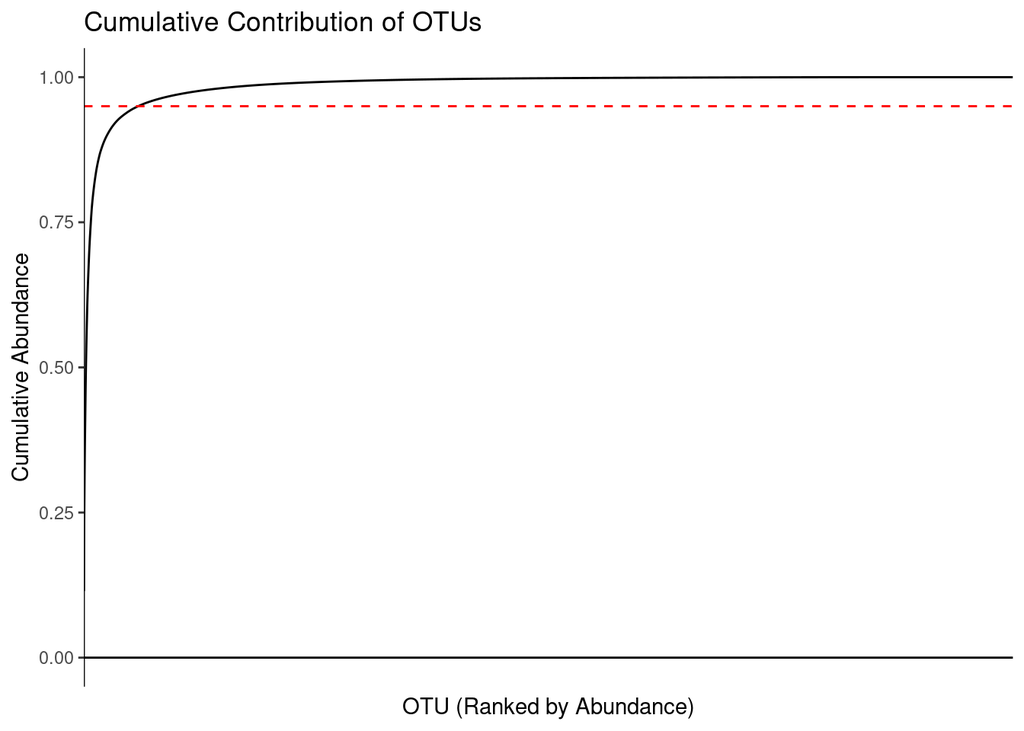

```r
# Plot cumulative contribution
ggplot(cumulative_otus, aes(x = reorder(OTU, -mean_abundance), y = cumulative_abundance, group = 1)) +
  geom_line() +
  geom_hline(yintercept = 0.95, linetype = "dashed", color = "red") +
  geom_hline(yintercept = 0, color = "black", linetype = "solid") +   # Add x-axis
  geom_vline(xintercept = 0, color = "black", linetype = "solid") +   # Add y-axis
  labs(title = "Cumulative Contribution of OTUs", x = "OTU (Ranked by Abundance)", y = "Cumulative Abundance") +
theme(axis.text.x = element_blank(), axis.ticks.x = element_blank()
)
```

We are going to keep the OTUs that made up until 95% of all the cumulative abundance. There are many OTUs that are very little represented, and so they hardly add nothing to the cumulative abundance. Those are the ones we are getting rid of:

```r
# Filter OTUs contributing to 95% cumulative abundance
otus_to_keep <- cumulative_otus |>
  filter(cumulative_abundance <= 0.95) |>
  pull(OTU)

# Filter the metadata to retain only these OTUs
filtered_metadata <- metadata_df_long |>
  filter(OTU %in% otus_to_keep)

head(filtered_metadata)
```

```
# A tibble: 6 × 8
  SampleID  Diet Source Donor CollectionMet   Sex OTU   rel_abundance
     <int> <int>  <int> <int>         <int> <int> <chr>         <dbl>
1        1     0      0     0             0     0 OTU6       3.31e-11
2        1     0      0     0             0     0 OTU7       5.08e-11
3        1     0      0     0             0     0 OTU9       2.57e- 3
4        1     0      0     0             0     0 OTU41      7.95e-11
5        1     0      0     0             0     0 OTU58      2.53e-11
6        1     0      0     0             0     0 OTU77      1.28e- 3
```

As a result, we get a data frame of $N = 264,600$ !

```r
# Number of OTUs before filtering
n_total_otus <- n_distinct(metadata_df_long$OTU)

# Number of OTUs after filtering
n_filtered_otus <- n_distinct(filtered_metadata$OTU)

# Print results
cat("Number of OTUs before filtering:", n_total_otus, "\n")
```

```
Number of OTUs before filtering: 6696
```

```r
cat("Number of OTUs after filtering:", n_filtered_otus, "\n")
```

```
Number of OTUs after filtering: 392
```

```r
cat("Number of OTUs removed:", n_total_otus - n_filtered_otus, "\n")
```

```
Number of OTUs removed: 6304
```

```r
cat("Percentage of OTUs removed:", (n_total_otus - n_filtered_otus) * 100 / n_total_otus, "% \n")
```

```
Percentage of OTUs removed: 94.14576 %
```

Filtering down from **6,696 OTUs to 392** (removing **6,304 OTUs**) might seem like a large loss, but this is often expected in microbiome datasets due to the nature of the data.

We check the distribution of OTU relative abundances to understand the range and frequency of abundance values after having filter them.

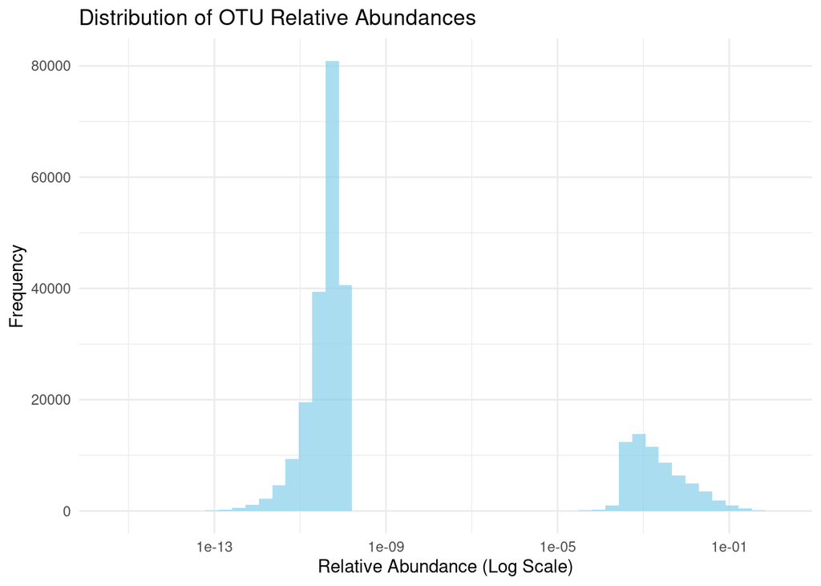

```r
# Distribution of OTU relative abundances
ggplot(filtered_metadata, aes(x = rel_abundance)) +
  geom_histogram(bins = 50, fill = "skyblue", alpha = 0.7) +
  scale_x_log10() +
  labs(title = "Distribution of OTU Relative Abundances", x = "Relative Abundance (Log Scale)", y = "Frequency") +
  theme_minimal()
```

Filter stricter because the distribution shows a large number of OTUs with extremely low relative abundances, likely representing noise or negligible contributors.

```r
# Set the stricter abundance threshold
abundance_threshold <- 1e-6
# Apply the threshold to filter OTUs
filtered_metadata_stricter <- filtered_metadata |>
  filter(rel_abundance >= abundance_threshold)
head(filtered_metadata_stricter)
```

```
# A tibble: 6 × 8
  SampleID  Diet Source Donor CollectionMet   Sex OTU    rel_abundance
     <int> <int>  <int> <int>         <int> <int> <chr>          <dbl>
1        1     0      0     0             0     0 OTU9        0.00257
2        1     0      0     0             0     0 OTU77       0.00128
3        1     0      0     0             0     0 OTU155      0.00449
4        1     0      0     0             0     0 OTU170      0.000641
5        1     0      0     0             0     0 OTU336      0.000641
6        1     0      0     0             0     0 OTU370      0.00257
```

As a result, we get a data frame of $N = 65,938$ !

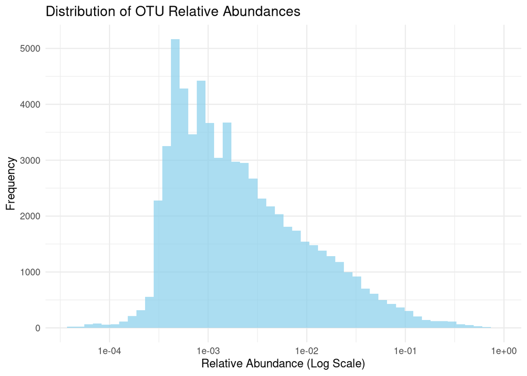

```r
# Plot the distribution of relative abundances after stricter filtering
ggplot(filtered_metadata_stricter, aes(x = rel_abundance)) +
  geom_histogram(bins = 50, fill = "skyblue", alpha = 0.7) +
  scale_x_log10() +
  labs(title = "Distribution of OTU Relative Abundances", x = "Relative Abundance (Log Scale)", y = "Frequency") +
  theme_minimal()
```

Finally, we can replace the numeric codes with descriptive labels. This includes variables such as Sex or Diet. To do so, we need the dictionary dataframe:

```r
filtered_metadata_stricter_label <- filtered_metadata_stricter|>
  mutate(Diet = case_when(Diet == 0 ~ "LFPP",
                          Diet == 1 ~ "Western",
                          Diet == 2 ~ "CARBR",
                          Diet == 3 ~ "FATR",
                          Diet == 4 ~ "Suckling",
                          Diet == 5 ~ "Human")) |>
  mutate(Source = case_when(Source == 0 ~ "Cecum1",
                          Source == 1 ~ "Cecum2",
                          Source == 2 ~ "Colon1",
                          Source == 3 ~ "Colon2",
                          Source == 4 ~ "Feces",
                          Source == 5 ~ "SI1",
                          Source == 6 ~ "SI13",
                          Source == 7 ~ "SI15",
                          Source == 8 ~ "SI2",
                          Source == 9 ~ "SI5",
                          Source == 10 ~ "CSI9",
                          Source == 11 ~ "Stomach",
                          Source == 12 ~ "Cecum")) |>
  mutate(Donor = case_when(Donor == 0 ~ "HMouseLFPP",
                          Donor == 1 ~ "CONVR",
                          Donor == 2 ~ "Human",
                          Donor == 3 ~ "Fresh",
                          Donor == 4 ~ "Frozen",
                          Donor == 5 ~ "HMouseWestern",
                          Donor == 6 ~ "CONVD")) |>
  mutate(CollectionMet = case_when(CollectionMet == 0 ~ "Contents",
                                   CollectionMet == 1 ~ "Scraping")) |>
  mutate(Sex = case_when(Sex == 0 ~ "Male",
                         Sex == 1 ~ "Female"))
```

Our dataset is now tidy! Let’s save the results.

```r
write.table(filtered_metadata_stricter, "../data/02_metadata_long_filtered.tsv", sep = "\t", quote = FALSE, col.names = NA)

write.table(filtered_metadata_stricter_label, "../data/02_metadata_long_filtered_label.tsv", sep = "\t", quote = FALSE, col.names = NA)
```

## Augment data

### 1. Load packages

### 2. Read data

```r
clean_df <- read.table('../data/02_metadata_long_filtered_label.tsv', header=TRUE, sep='\t')
head(clean_df)
```

```
  X SampleID Diet Source      Donor CollectionMet  Sex    OTU rel_abundance
1 1        1 LFPP Cecum1 HMouseLFPP      Contents Male   OTU9   0.002565747
2 2        1 LFPP Cecum1 HMouseLFPP      Contents Male  OTU77   0.001282874
3 3        1 LFPP Cecum1 HMouseLFPP      Contents Male OTU155   0.004490058
4 4        1 LFPP Cecum1 HMouseLFPP      Contents Male OTU170   0.000641437
5 5        1 LFPP Cecum1 HMouseLFPP      Contents Male OTU336   0.000641437
6 6        1 LFPP Cecum1 HMouseLFPP      Contents Male OTU370   0.002565747
```

In this section, we’ll be working with the OTUs taxonomy file, so let’s load it as well.

```r
otu_df_original <- read.table('../data/01_data_otu.tsv', header = TRUE, sep = ",")
head(otu_df_original)
```

```
  OTU.ID  Kingdom        Phylum         Class           Order
1   OTU0 Bacteria
2   OTU1 Bacteria    Firmicutes    Clostridia   Clostridiales
3   OTU2 Bacteria    Firmicutes       Bacilli Lactobacillales
4   OTU3 Bacteria Bacteroidetes Bacteroidetes   Bacteroidales
5   OTU4 Bacteria Bacteroidetes
6   OTU5 Bacteria    Firmicutes    Clostridia   Clostridiales
              Family           Genus X X.1
1
2    Ruminococcaceae
3    Enterococcaceae    Enterococcus
4 Porphyromonadaceae Parabacteroides
5
6
```

If we do a deeper analysis of this dataset, we can actually check it is very ill-defined, if not directly erroneous. An example can be seen on OTU94, which presents several problems:

```r
otu_df_original |>
  filter(OTU.ID == "OTU94")
```

```
  OTU.ID  Kingdom         Phylum          Class            Order
1  OTU94 Bacteria Actinobacteria Actinobacteria Actinobacteridae
           Family      Genus                   X          X.1
1 Actinomycetales Frankineae Geodermatophilaceae Blastococcus
```

The information from this OTU is the following:

- Kingdom: Bacteria
- Phyllum: Actinobacteria
- Class: Actinobacteria

Here comes the first problems: they chose the same term for the phyllum and class! This is misleading and unnecessarily confusing. For disambiguate, the following synonyms could have been used instead: Actinomycetota for the phyllum and Actinomycetia for the class.

- Order: Actinobacteridae

Actinobacteridae is actually a subclass, which is no longer in use (see https://lpsn.dsmz.de/subclass/actinobacteridae).

- Family: Actinomycetales

Actinomycetales is actually an order, not a family.

- Genus: Frankineae

Frankineae is an order, not a genus, and it is different from the previous order mentioned.

Additionally, there are two extra columns with no identification of taxonomy: Geodermatophilaceae and Blastococcus.

Such delirium of dataset is the result of complete lack of manual curation and care. Different actions need to be taken to make sense of the biological data.

We decide to work only with the phylum and class, as these taxonomical categories are the ones being used for results presentation in the reference paper we are working with.

```r
otu_df_modified <-  otu_df_original |>
  select(OTU.ID, Phylum, Class) |>
  mutate(Phylum = if_else(Phylum == "", "Unclassified", Phylum)) |>
  mutate(Class = if_else(Class == "", "Unclassified", Class))

otu_df_modified
```

```
      OTU.ID              Phylum                     Class
1       OTU0        Unclassified              Unclassified
2       OTU1          Firmicutes                Clostridia
3       OTU2          Firmicutes                   Bacilli
4       OTU3       Bacteroidetes             Bacteroidetes
5       OTU4       Bacteroidetes              Unclassified
6       OTU5          Firmicutes                Clostridia
7       OTU6          Firmicutes                   Bacilli
8       OTU7          Firmicutes                Clostridia
9       OTU8          Firmicutes                Clostridia
10      OTU9          Firmicutes                Clostridia
11     OTU10          Firmicutes                Clostridia
12     OTU11          Firmicutes                Clostridia
13     OTU12        Unclassified              Unclassified
14     OTU13          Firmicutes                Clostridia
```

[output cut: 6682 more lines]

After that, we perform a left join to include the taxonomical information to the data frame:

```r
clean_df <- clean_df |>
  left_join(otu_df_modified,
            join_by(OTU == OTU.ID)) |>
  relocate(Phylum, Class, .after = OTU)
```

```r
write.table(clean_df, "../data/03_metadata_long_filtered_taxonom.tsv", sep = "\t", quote = FALSE, col.names = NA)
```

## Description and Visualization

## Data visualization and description

1. Load packages
2. Read data

   ```r
   clean_df <- read.table('../data/03_metadata_long_filtered_taxonom.tsv', header=TRUE, sep='\t')
   head(clean_df)
   ```

   ```
     X.1 X SampleID Diet Source      Donor CollectionMet  Sex    OTU        Phylum
   1   1 1        1 LFPP Cecum1 HMouseLFPP      Contents Male   OTU9    Firmicutes
   2   2 2        1 LFPP Cecum1 HMouseLFPP      Contents Male  OTU77    Firmicutes
   3   3 3        1 LFPP Cecum1 HMouseLFPP      Contents Male OTU155    Firmicutes
   4   4 4        1 LFPP Cecum1 HMouseLFPP      Contents Male OTU170    Firmicutes
   5   5 5        1 LFPP Cecum1 HMouseLFPP      Contents Male OTU336    Firmicutes
   6   6 6        1 LFPP Cecum1 HMouseLFPP      Contents Male OTU370 Bacteroidetes
             Class rel_abundance
   1    Clostridia   0.002565747
   2    Clostridia   0.001282874
   3    Clostridia   0.004490058
   4    Clostridia   0.000641437
   5    Clostridia   0.000641437
   6 Bacteroidetes   0.002565747
   ```

   ```r
   raw_data <- read.table('../data/01_data_metadata.tsv', header=TRUE, sep='\t')
   head(raw_data)
   ```

   ```
     Diet Source Donor CollectionMet Sex     OTU0     OTU1     OTU2     OTU3
   1    0      0     0             0   0 1.56e-11 4.72e-11 1.23e-11 4.52e-11
   2    0      1     0             0   0 2.36e-11 9.53e-11 3.33e-11 2.67e-11
   3    0      2     0             1   0 6.77e-11 3.68e-11 8.02e-11 5.49e-11
   4    0      2     0             0   0 5.52e-11 9.89e-11 4.58e-11 3.54e-11
   5    0      3     0             0   0 5.24e-11 6.34e-11 2.35e-11 7.47e-11
   6    0      4     0             1   0 7.67e-11 7.22e-11 5.41e-11 1.20e-11
         OTU4     OTU5     OTU6     OTU7     OTU8        OTU9    OTU10    OTU11
   1 2.72e-11 2.71e-11 3.31e-11 5.08e-11 1.85e-11 0.002565747 3.44e-11 3.67e-11
   2 2.02e-11 2.51e-11 6.75e-11 9.08e-11 8.71e-11 0.000251636 7.47e-11 1.55e-11
   3 1.34e-11 5.12e-11 5.81e-11 6.47e-11 1.45e-11 0.002336449 6.68e-11 3.39e-11
   4 2.09e-11 6.26e-11 9.34e-11 5.37e-11 6.28e-11 0.000741015 4.36e-11 6.14e-11
   5 2.49e-11 4.05e-13 3.34e-11 8.50e-12 4.56e-11 0.000493340 6.70e-11 7.78e-12
   6 4.54e-11 1.27e-11 1.92e-11 9.52e-11 1.34e-11 0.000767460 7.46e-11 6.56e-11
        OTU12    OTU13    OTU14    OTU15    OTU16    OTU17    OTU18    OTU19
   ```

   [output cut: 5872 more lines]

### Abundance of OTUs in samples using phyla and class

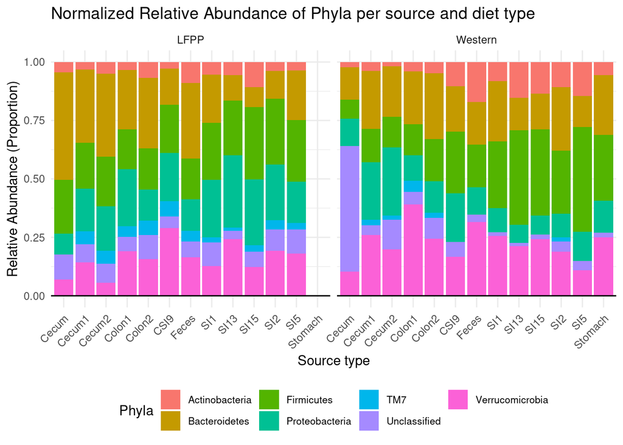

```r
clean_df |>
  filter(Diet %in% c("LFPP", "Western")) |>
  group_by(Source, Diet) |>
  mutate(norm_rel_abundance = rel_abundance / sum(rel_abundance)) |> # Normalize abundance within samples
  group_by(Source, Diet, Phylum) |>
  summarise(mean_rel_abund = mean(norm_rel_abundance), .groups = "drop") |> # Calculate the mean relative abundances
  group_by(Source, Diet) |>
  mutate(mean_rel_abund = mean_rel_abund / sum(mean_rel_abund)) |> # Normalize mean abundances so that the total for each one is 1
  ggplot(aes(x = Source,
             y = mean_rel_abund,
             fill = Phylum)) +
  geom_bar(stat = "identity",
           position = "stack") +
  geom_hline(yintercept = 0) +
  facet_wrap(~ Diet) +
  labs(
    title = "Normalized Relative Abundance of Phyla per source and diet type",
    x = "Source type",
    y = "Relative Abundance (Proportion)",
    fill = "Phyla"
  ) +
  theme_minimal() +
  theme(legend.position = "bottom", # change when data augmentation has been done
        legend.text = element_text(size = 8),
        axis.text.x = element_text(angle = 45, hjust = 1))
```

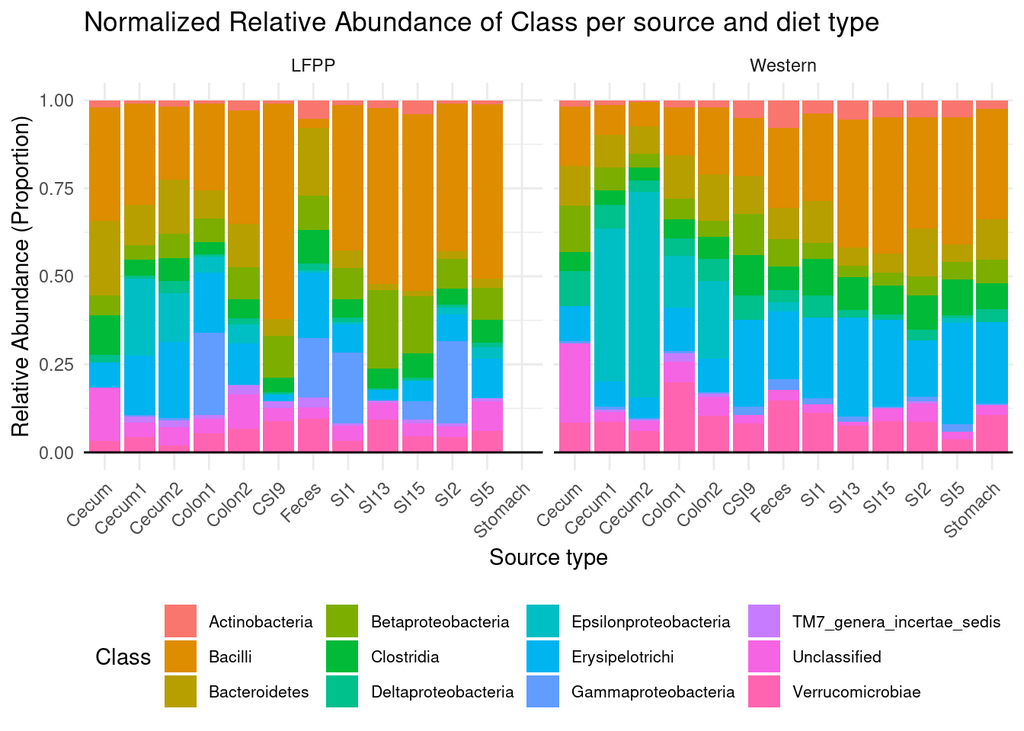

```r
clean_df |>
  filter(Diet %in% c("LFPP", "Western")) |>
  group_by(Source, Diet) |>
  mutate(norm_rel_abundance = rel_abundance / sum(rel_abundance)) |> # Normalize abundance within samples
  group_by(Source, Diet, Class) |>
  summarise(mean_rel_abund = mean(norm_rel_abundance), .groups = "drop") |> # Calculate the mean relative abundances
  group_by(Source, Diet) |>
  mutate(mean_rel_abund = mean_rel_abund / sum(mean_rel_abund)) |> # Normalize mean abundances so that the total for each one is 1
  ggplot(aes(x = Source,
             y = mean_rel_abund,
             fill = Class)) +
  geom_bar(stat = "identity",
           position = "stack") +
  geom_hline(yintercept = 0) +
  facet_wrap(~ Diet) +
  labs(
    title = "Normalized Relative Abundance of Class per source and diet type",
    x = "Source type",
    y = "Relative Abundance (Proportion)",
    fill = "Class"
  ) +
  theme_minimal() +
  theme(legend.position = "bottom", # change when data augmentation has been done
        legend.text = element_text(size = 8),
        axis.text.x = element_text(angle = 45, hjust = 1))
```

### Microbiota composition of mice with different diet and donor combination (relative abundance of phyla)

In order to compare the general composition of the microbiota in the mice with different donor and diet, we may represent the relative abundance of the most prevalent phyla.

For this purpose we will use the clean data.

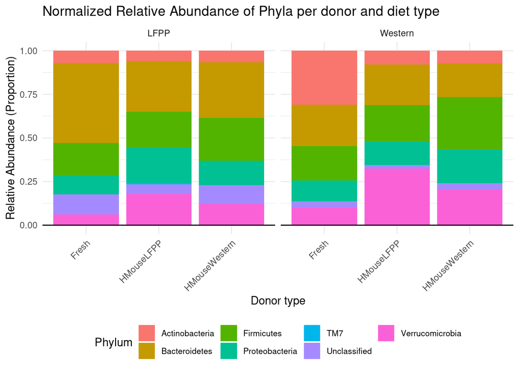

```r
clean_df |>
  filter(Diet %in% c("LFPP", "Western") & Donor %in% c("Fresh", "HMouseLFPP", "HMouseWestern") & Source != "Fresh" ) |>
  group_by(Donor, Diet) |>
  mutate(norm_rel_abundance = rel_abundance / sum(rel_abundance)) |> # Normalize abundance within samples
  group_by(Donor, Diet, Phylum) |>
  summarise(mean_rel_abund = mean(norm_rel_abundance), .groups = "drop") |> # Calculate the mean relative abundances
  group_by(Donor, Diet) |>
  mutate(mean_rel_abund = mean_rel_abund / sum(mean_rel_abund)) |> # Normalize mean abundances so that the total for each one is 1
  ggplot(aes(x = Donor,
             y = mean_rel_abund,
             fill = Phylum)) +
  geom_bar(stat = "identity",
           position = "stack") +
  geom_hline(yintercept = 0) +
  facet_wrap(~ Diet) +
  labs(
    title = "Normalized Relative Abundance of Phyla per donor and diet type",
    x = "Donor type",
    y = "Relative Abundance (Proportion)",
    fill = "Phylum"
  ) +
  theme_minimal() +
  theme(legend.position = "bottom", # change when data augmentation has been done
        legend.text = element_text(size = 8),
        axis.text.x = element_text(angle = 45, hjust = 1))
```

### Biodiversity of humanised mice microbiota with different diet

We can use diversity indices in order to quantify biodiversity. As we know the relative abundance of each OTU, we can use the Shannon diversity index. Based on Claude Shannon’s formula for entropy, this popular ecological metric takes into account the number of species living in a habitat (richness) and their relative abundance (evenness).

The formula we will use is:

$$H' = -\sum_{i=1}^R p_i \ln p_i \\
p_i \text{ is the relative abundance of OTU}_i\\ R \text{ is the total number of OTUs}$$

We will compare this index for first generation humanised mice following each diet. For this purpose, we will use the original raw data, in which all OTU counts (including the less abundant ones) are included.

We first store the diet column in a dataframe.

```r
diet_data <- raw_data |>
  filter(Donor == 3 & Source != 4 & Diet %in% c(0, 1)) |> #we select 1st generation humanised mice (donor is fresh), get rid of microbiota samples that were not taken at the time of sacrifice (source is not fecal), and we select the LFPP (0) and Western (1) diets
  select(Diet) |>
  mutate(Diet = case_when(Diet == 0 ~ "LFPP",
                          Diet == 1 ~ "Western"))
```

We calculate the Shannon index for each row and save it in a new dataframe.

```r
shannon <- raw_data |>
  filter(Donor == 3 & Source != 4 & Diet %in% c(0, 1)) |> #same filters as before
  select(starts_with("OTU")) |> #we only need the OTU columns to calculate the index
  mutate(across(everything(), ~ (-1)*.x * log(.x))) |> #we transform each OTU relative abundance column (p_i) into p_i*log(p_i)
  rowwise() |> #we apply the following operations row by row
  mutate(
    sum_all_columns = sum(across(everything()), na.rm = TRUE), #we add the products to calculate the shannon_index
    .keep = "unused") |> #we only keep the new shannon index column
  ungroup()
shannon
```

```
# A tibble: 14 × 1
   sum_all_columns
             <dbl>
 1            3.18
 2            2.68
 3            2.94
 4            2.81
 5            3.02
 6            3.03
 7            3.01
 8            3.55
 9            3.60
10            3.86
11            2.54
12            2.83
13            3.58
14            3.56
```

We combine both dataframes and calculate the Shannon index and its standard deviation for each diet.

```r
combined_df <- bind_cols(diet_data, shannon)  #combination of both dataframes
final_shannon <- combined_df |> #generate a final data frame with the shannon index and sd for each diet
  group_by(Diet) |>
  summarise(
    shannon_index= mean(sum_all_columns),
    standard_dev = sd(sum_all_columns)
  )
final_shannon
```

```
# A tibble: 2 × 3
  Diet    shannon_index standard_dev
  <chr>           <dbl>        <dbl>
1 LFPP             2.89        0.198
2 Western          3.63        0.128
```

Finally, we plot the index for each of the studied diets.

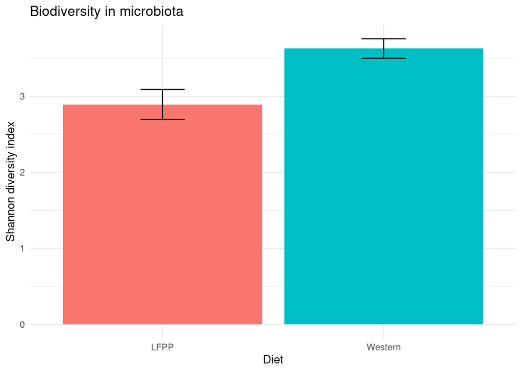

```r
# Plot with error bars
ggplot(final_shannon, aes(x = Diet, y = shannon_index)) +
  geom_col(aes(fill=Diet)) +
  geom_errorbar(aes(ymin = shannon_index - standard_dev, ymax = shannon_index + standard_dev), width = 0.2) +  # Error bars
  labs(
    title = "Biodiversity in microbiota",
    x = "Diet",
    y = "Shannon diversity index"
  ) +
  theme_minimal() +
  theme(legend.position = "none")
```

Interestingly, the Western diet leads to a more biodiverse microbiota than the “healthier” LF-PP diet in the humanised mice.

## Analysis 1

```r
library("tidyverse")
library("ggrepel")
library("ggtext")
library("broom")
```

We want to test if there are differences in the relative abundance of the OTUs belonging to Firmicutes/Bacteroidetes depending on the diets LFPP or Western.

First, we will filter for the two kinds of diet and the two types of phyla we are going to be working with:

```r
clean_df_filtered_analysis <-
  clean_df |>
  filter(Phylum == "Firmicutes" | Phylum == "Bacteroidetes") |>
  filter(Diet == "LFPP" | Diet == "Western") |>
  mutate(Diet = case_when(Diet == "LFPP" ~ 0,
                         Diet == "Western" ~ 1))
```

```r
clean_df_filtered_nested <- clean_df_filtered_analysis |>
  group_by(OTU) |>
  nest() |>
  ungroup()
```

```r
clean_df_filtered_nested <- clean_df_filtered_nested |>
  group_by(OTU) |>
  mutate(model_object = map (.x = data,
                             .f = ~lm(formula = rel_abundance ~ Diet,
                                      data = .x)))
```

```r
otus_estimate <- clean_df_filtered_nested |>
  mutate(model_object_tidy = map(.x = model_object,
                                 .f = ~tidy(.x, conf.int = TRUE, conf.level = 0.95))
  ) |>
  unnest(model_object_tidy) |>
  filter(term == "Diet") |>
  select (OTU, p.value, estimate, conf.low, conf.high) |>
  ungroup() |>
  mutate(
    # Adjust p-values
    q.value = p.adjust(p.value),
    is_significant = case_when(
      q.value >= 0.05 ~ "no",
      q.value < 0.05 ~ "yes"
      )
  )
```

## Analysis 2